# padmaska_m5_as3

Artsiom Padmaska

2024-01-23

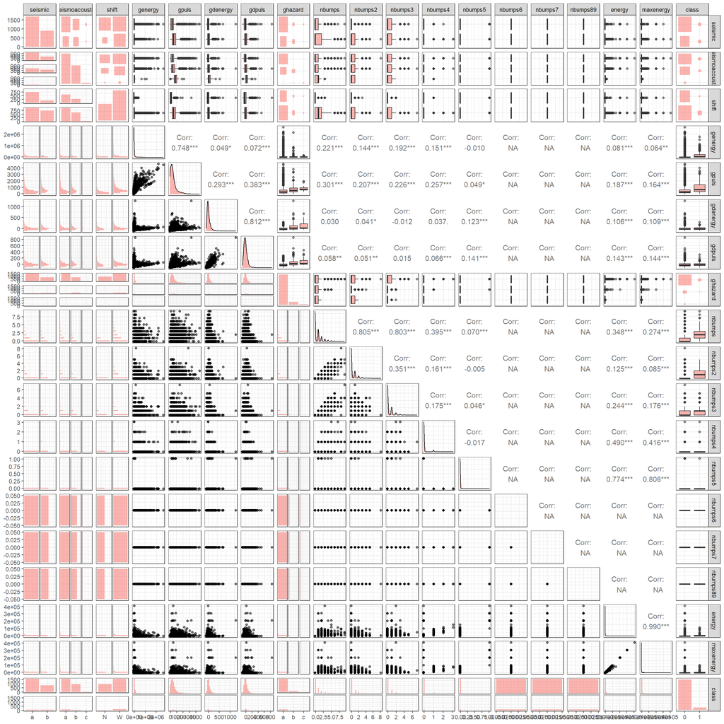

diagonal cells for nbumps >=6 don’t have nothing, let’s check if they have anything but 0

```r
unique(seismic_data$nbumps6)
```

```
## [1] 0
```

```r
unique(seismic_data$nbumps7)
```

```
## [1] 0
```

```r
unique(seismic_data$nbumps89)
```

```
## [1] 0
```

There are only 0-s, so we need to delete this features. Also, let’s check if the binary + nbumps features balanced?

```r
ftable(seismic_data$seismic, seismic_data$class)
```

```
##       0    1
##
## a  1599   83
## b   815   87
```

```r
ftable(seismic_data$seismoacoustic, seismic_data$class)
```

```
##       0    1
##
## a  1479  101
## b   890   66
## c    45    3
```

```r
ftable(seismic_data$shift, seismic_data$class)
```

```
##       0    1
##
## N   904   17
## W  1510  153
```

```r
ftable(seismic_data$ghazard, seismic_data$class)
```

```
##       0    1
##
## a  2186  156
## b   198   14
## c    30    0
```

```r
ftable(seismic_data$ghazard, seismic_data$nbumps)
```

```
##       0    1    2    3    4    5    6    7    8    9
##
## a  1317  540  220  122   66   34   28    5    7    3
## b   131   47   22    5    3    4    0    0    0    0
## c    16   11    3    0    0    0    0    0    0    0
```

```r
ftable(seismic_data$ghazard, seismic_data$nbumps2)
```

```
##       0    1    2    3    4    5    8
##
## a  1720  411  141   52   11    6    1
## b   161   35    9    6    1    0    0
## c    20    9    1    0    0    0    0
```

```r
ftable(seismic_data$ghazard, seismic_data$nbumps3)
```

```
##       0    1    2    3    4    5    7
##
## a  1685  454  135   42   20    5    1
## b   169   39    4    0    0    0    0
## c    25    4    1    0    0    0    0
```

```r
ftable(seismic_data$ghazard, seismic_data$nbumps4)
```

```
##       0    1    2    3
##
## a  2198  129   13    2
## b   198   14    0    0
## c    30    0    0    0
```

```r
ftable(seismic_data$ghazard, seismic_data$nbumps5)
```

```
##       0    1
##
## a  2332   10
## b   210    2
## c    30    0
```

Only 48 result of shift obtained by the seismoacoustic method and 30 based on registration coming form GMax only are high hazard. We won’t be able to reliably estimate a coefficient of this feature, so I’ll make result c be result b.

```r
seismic_data$seismoacoustic[seismic_data$seismoacoustic == "c"] <- "b"
seismic_data$ghazard[seismic_data$ghazard == "c"] <- "b"
```

Standard Poisson model:

```
##
## Call:
## glm(formula = class ~ ., family = poisson(), data = seismic_data)
##
## Coefficients:
##                   Estimate Std. Error z value Pr(>|z|)
## (Intercept)     -4.352e+00  2.633e-01 -16.529  < 2e-16 ***
## seismicb         2.647e-01  1.704e-01   1.554 0.120299
## seismoacousticb  4.314e-02  1.710e-01   0.252 0.800803
## shiftW           9.360e-01  2.812e-01   3.329 0.000873 ***
## genergy         -4.174e-07  3.726e-07  -1.120 0.262569
## gpuls            6.438e-04  1.716e-04   3.752 0.000176 ***
## gdenergy        -9.417e-04  1.991e-03  -0.473 0.636215
## gdpuls          -1.748e-03  2.667e-03  -0.655 0.512277
## ghazardb        -5.649e-02  3.123e-01  -0.181 0.856434
## nbumps           3.199e+00  1.039e+00   3.079 0.002080 **
## nbumps2         -2.930e+00  1.043e+00  -2.810 0.004958 **
## nbumps3         -2.853e+00  1.041e+00  -2.741 0.006117 **
## nbumps4         -3.046e+00  1.104e+00  -2.759 0.005803 **
## nbumps5         -1.751e+00  2.218e+00  -0.789 0.429836
## energy          -1.354e-05  2.909e-05  -0.465 0.641650
## maxenergy        7.713e-06  2.873e-05   0.268 0.788319
## ---
## Signif. codes:  0 '***' 0.001 '**' 0.01 '*' 0.05 '.' 0.1 ' ' 1
##
## (Dispersion parameter for poisson family taken to be 1)
##
##     Null deviance: 925.24  on 2583  degrees of freedom
## Residual deviance: 771.25  on 2568  degrees of freedom
## AIC: 1143.2
##
## Number of Fisher Scoring iterations: 6
```

```r
1 - m1$deviance / m1$null.deviance
```

```
## [1] 0.1664344
```

```
##
## Call:
## glm(formula = class ~ shift + gpuls + nbumps + nbumps2 + nbumps3 +
##     nbumps4, family = poisson(), data = seismic_data)
##
## Coefficients:
##               Estimate Std. Error z value Pr(>|z|)
## (Intercept) -4.204e+00  2.445e-01 -17.193  < 2e-16 ***
## shiftW       9.644e-01  2.709e-01   3.560 0.000371 ***
## gpuls        4.495e-04  9.101e-05   4.939 7.87e-07 ***
## nbumps       7.280e-01  7.133e-01   1.021 0.307434
## nbumps2     -4.479e-01  7.135e-01  -0.628 0.530177
## nbumps3     -4.111e-01  7.182e-01  -0.572 0.567088
## nbumps4     -7.161e-01  7.319e-01  -0.978 0.327862
## ---
## Signif. codes:  0 '***' 0.001 '**' 0.01 '*' 0.05 '.' 0.1 ' ' 1
##
## (Dispersion parameter for poisson family taken to be 1)
##
##     Null deviance: 925.24  on 2583  degrees of freedom
## Residual deviance: 782.79  on 2577  degrees of freedom
## AIC: 1136.8
##
## Number of Fisher Scoring iterations: 6
```

Testing the hypothesis of equidispersion against the alternative of overdispersion:

```
##
##  Overdispersion test
##
## data:  m1
## z = -6.9298, p-value = 1
## alternative hypothesis: true dispersion is greater than 1
## sample estimates:
## dispersion
##  0.9342105
```

p-value > 0.05, so we can reject overdispersion

```r
1 - m2$deviance / m2$null.deviance
```

```
## [1] 0.1539566
```

```r
lrtest(m1,m2)
```

```
## Likelihood ratio test
##
## Model 1: class ~ seismic + seismoacoustic + shift + genergy + gpuls +
##     gdenergy + gdpuls + ghazard + nbumps + nbumps2 + nbumps3 +
##     nbumps4 + nbumps5 + energy + maxenergy
## Model 2: class ~ shift + gpuls + nbumps + nbumps2 + nbumps3 + nbumps4
##   #Df  LogLik Df  Chisq Pr(>Chisq)
## 1  16 -555.62
## 2   7 -561.40 -9 11.545     0.2402
```

no significant difference, so m2 is not worse than m1

```r
add1(m2, ~ . + seismic + seismoacoustic + genergy + gdenergy + gdpuls + ghazard + nbumps5 + energy + maxenergy, test="LRT")
```

```
## Single term additions
##
## Model:
## class ~ shift + gpuls + nbumps + nbumps2 + nbumps3 + nbumps4
##                Df Deviance    AIC    LRT Pr(>Chi)
## <none>              782.79 1136.8
## seismic         1   779.40 1135.4 3.3890  0.06563 .
## seismoacoustic  1   782.75 1138.8 0.0456  0.83082
## genergy         1   781.71 1137.7 1.0844  0.29772
## gdenergy        1   780.33 1136.3 2.4630  0.11656
## gdpuls          1   780.54 1136.5 2.2516  0.13347
## ghazard         1   782.64 1138.6 0.1553  0.69356
## nbumps5         1   778.90 1134.9 3.8903  0.04857 *
## energy          1   779.26 1135.3 3.5299  0.06027 .
## maxenergy       1   779.67 1135.7 3.1235  0.07717 .
## ---
## Signif. codes:  0 '***' 0.001 '**' 0.01 '*' 0.05 '.' 0.1 ' ' 1
```

```
##
## Call:
## glm(formula = class ~ shift + gpuls + nbumps + nbumps2 + nbumps3 +
##     nbumps4 + nbumps5, family = poisson(), data = seismic_data)
##
## Coefficients:
##               Estimate Std. Error z value Pr(>|z|)
## (Intercept) -4.252e+00  2.515e-01 -16.908  < 2e-16 ***
## shiftW       1.016e+00  2.778e-01   3.656 0.000256 ***
## gpuls        4.526e-04  9.117e-05   4.964  6.9e-07 ***
## nbumps       3.354e+00  1.031e+00   3.252 0.001146 **
## nbumps2     -3.078e+00  1.035e+00  -2.973 0.002950 **
## nbumps3     -3.035e+00  1.032e+00  -2.940 0.003280 **
## nbumps4     -3.348e+00  1.050e+00  -3.190 0.001425 **
## nbumps5     -3.281e+00  1.433e+00  -2.289 0.022098 *
## ---
## Signif. codes:  0 '***' 0.001 '**' 0.01 '*' 0.05 '.' 0.1 ' ' 1
##
## (Dispersion parameter for poisson family taken to be 1)
##
##     Null deviance: 925.24  on 2583  degrees of freedom
## Residual deviance: 778.90  on 2576  degrees of freedom
## AIC: 1134.9
##
## Number of Fisher Scoring iterations: 6
```

```r
1 - m3$deviance / m3$null.deviance
```

```
## [1] 0.1581612
```

```r
lrtest(m3,m2)
```

```
## Likelihood ratio test
##
## Model 1: class ~ shift + gpuls + nbumps + nbumps2 + nbumps3 + nbumps4 +
##     nbumps5
## Model 2: class ~ shift + gpuls + nbumps + nbumps2 + nbumps3 + nbumps4
##   #Df  LogLik Df  Chisq Pr(>Chisq)
## 1   8 -559.45
## 2   7 -561.40 -1 3.8903    0.04857 *
## ---
## Signif. codes:  0 '***' 0.001 '**' 0.01 '*' 0.05 '.' 0.1 ' ' 1
```

model 3 is significantly better than model 2

```r
lrtest(m1,m3)
```

```
## Likelihood ratio test
##
## Model 1: class ~ seismic + seismoacoustic + shift + genergy + gpuls +
##     gdenergy + gdpuls + ghazard + nbumps + nbumps2 + nbumps3 +
##     nbumps4 + nbumps5 + energy + maxenergy
## Model 2: class ~ shift + gpuls + nbumps + nbumps2 + nbumps3 + nbumps4 +
##     nbumps5
##   #Df  LogLik Df  Chisq Pr(>Chisq)
## 1  16 -555.62
## 2   8 -559.45 -8 7.6547     0.4679
```

model 3 is not worse than model 1

```r
add1(m3, ~ . + seismic + seismoacoustic + genergy + gdenergy + gdpuls + ghazard + energy + maxenergy, test="LRT")
```

```
## Single term additions
##
## Model:
## class ~ shift + gpuls + nbumps + nbumps2 + nbumps3 + nbumps4 +
##     nbumps5
##                Df Deviance    AIC    LRT Pr(>Chi)
## <none>              778.90 1134.9
## seismic         1   775.73 1133.7 3.1752  0.07476 .
## seismoacoustic  1   778.88 1136.9 0.0277  0.86793
## genergy         1   777.63 1135.6 1.2705  0.25967
## gdenergy        1   776.90 1134.9 2.0080  0.15647
## gdpuls          1   777.03 1135.0 1.8731  0.17112
## ghazard         1   778.78 1136.8 0.1230  0.72583
## energy          1   778.46 1136.5 0.4419  0.50621
## maxenergy       1   778.63 1136.6 0.2705  0.60302
## ---
## Signif. codes:  0 '***' 0.001 '**' 0.01 '*' 0.05 '.' 0.1 ' ' 1
```

None provides a significant improvement.

```
## Single term additions
##
## Model:
## class ~ shift + gpuls + nbumps + nbumps2 + nbumps3 + nbumps4 +
##     nbumps5
##                 Df Deviance    AIC     LRT  Pr(>Chi)
## <none>               778.90 1134.9
## shift:gpuls      1   778.80 1136.8  0.1041 0.7469867
## shift:nbumps     1   770.15 1128.2  8.7529 0.0030912 **
## shift:nbumps2    1   776.09 1134.1  2.8101 0.0936729 .
## shift:nbumps3    1   774.69 1132.7  4.2087 0.0402177 *
## shift:nbumps4    1   772.51 1130.5  6.3982 0.0114235 *
## shift:nbumps5    1   778.54 1136.5  0.3632 0.5467357
## gpuls:nbumps     1   773.95 1132.0  4.9485 0.0261138 *
## gpuls:nbumps2    1   776.48 1134.5  2.4239 0.1194969
## gpuls:nbumps3    1   775.46 1133.5  3.4391 0.0636704 .
## gpuls:nbumps4    1   778.69 1136.7  0.2125 0.6448201
## gpuls:nbumps5    1   778.86 1136.9  0.0453 0.8313797
## nbumps:nbumps2   1   767.18 1125.2 11.7254 0.0006165 ***
## nbumps:nbumps3   1   772.99 1131.0  5.9129 0.0150303 *
## nbumps:nbumps4   1   778.69 1136.7  0.2141 0.6436063
## nbumps:nbumps5   1   778.64 1136.6  0.2594 0.6105297
## nbumps2:nbumps3  1   776.42 1134.4  2.4793 0.1153543
## nbumps2:nbumps4  1   778.90 1136.9  0.0002 0.9897612
## nbumps2:nbumps5  1   778.47 1136.5  0.4310 0.5114750
## nbumps3:nbumps4  1   777.95 1136.0  0.9578 0.3277456
## nbumps3:nbumps5  1   776.45 1134.5  2.4576 0.1169595
## nbumps4:nbumps5  0   778.90 1134.9  0.0000
## ---
## Signif. codes:  0 '***' 0.001 '**' 0.01 '*' 0.05 '.' 0.1 ' ' 1
```

```
##
## Call:
## glm(formula = class ~ shift + gpuls + nbumps + nbumps2 + nbumps3 +
##     nbumps4 + nbumps5 + shift * nbumps + shift * nbumps3 + shift *
##     nbumps4 + gpuls * nbumps + nbumps * nbumps2 + nbumps * nbumps3,
##     family = poisson(), data = seismic_data)
##
## Coefficients:
##                  Estimate Std. Error z value Pr(>|z|)
## (Intercept)    -4.961e+00  3.769e-01 -13.163  < 2e-16 ***
## shiftW          1.360e+00  4.142e-01   3.283 0.001027 **
## gpuls           6.244e-04  1.569e-04   3.980 6.88e-05 ***
## nbumps          3.613e+00  1.082e+00   3.338 0.000843 ***
## nbumps2        -2.510e+00  1.247e+00  -2.014 0.044018 *
## nbumps3        -2.206e+00  1.063e+00  -2.075 0.037995 *
## nbumps4        -6.441e-01  1.242e+00  -0.519 0.604047
## nbumps5        -3.316e+00  1.569e+00  -2.114 0.034520 *
## shiftW:nbumps  -3.361e-01  4.550e-01  -0.739 0.460021
## shiftW:nbumps3 -4.653e-01  6.732e-01  -0.691 0.489514
## shiftW:nbumps4 -2.487e+00  9.361e-01  -2.657 0.007891 **
## gpuls:nbumps   -7.962e-05  5.317e-05  -1.497 0.134305
## nbumps:nbumps2 -7.226e-02  3.447e-02  -2.096 0.036044 *
## nbumps:nbumps3 -3.010e-02  3.344e-02  -0.900 0.368117
## ---
## Signif. codes:  0 '***' 0.001 '**' 0.01 '*' 0.05 '.' 0.1 ' ' 1
##
## (Dispersion parameter for poisson family taken to be 1)
##
##     Null deviance: 925.24  on 2583  degrees of freedom
## Residual deviance: 752.44  on 2570  degrees of freedom
## AIC: 1120.4
##
## Number of Fisher Scoring iterations: 6
```

```
## Likelihood ratio test
##
## Model 1: class ~ shift + gpuls + nbumps + nbumps2 + nbumps3 + nbumps4 +
##     nbumps5
## Model 2: class ~ shift + gpuls + nbumps + nbumps2 + nbumps3 + nbumps4 +
##     nbumps5 + shift * nbumps + shift * nbumps3 + shift * nbumps4 +
##     gpuls * nbumps + nbumps * nbumps2 + nbumps * nbumps3
##   #Df  LogLik Df  Chisq Pr(>Chisq)
## 1   8 -559.45
## 2  14 -546.22  6 26.467  0.0001822 ***
## ---
## Signif. codes:  0 '***' 0.001 '**' 0.01 '*' 0.05 '.' 0.1 ' ' 1
```

$R^2_{DEV}$

```r
1 - m4$deviance / m4$null.deviance
```

```
## [1] 0.1867665
```

```
## Single term additions
##
## Model:
## class ~ shift + gpuls + nbumps + nbumps2 + nbumps3 + nbumps4 +
##     nbumps5 + shift * nbumps + shift * nbumps3 + shift * nbumps4 +
##     gpuls * nbumps + nbumps * nbumps2 + nbumps * nbumps3
##                      Df Deviance    AIC     LRT Pr(>Chi)
## <none>                    752.44 1120.4
## shift:gpuls           1   751.23 1121.2 1.20608  0.27211
## shift:nbumps2         1   751.79 1121.8 0.64756  0.42099
## shift:nbumps5         1   751.79 1121.8 0.64756  0.42099
## gpuls:nbumps2         1   751.77 1121.8 0.66429  0.41505
## gpuls:nbumps3         1   751.92 1121.9 0.51263  0.47400
## gpuls:nbumps4         1   752.43 1122.4 0.00260  0.95929
## gpuls:nbumps5         1   752.33 1122.3 0.10348  0.74769
## nbumps:nbumps4        1   751.29 1121.3 1.15148  0.28324
## nbumps:nbumps5        1   752.12 1122.1 0.31575  0.57417
## nbumps2:nbumps3       1   752.27 1122.3 0.16867  0.68130
## nbumps2:nbumps4       1   750.83 1120.8 1.60323  0.20545
## nbumps2:nbumps5       1   752.00 1122.0 0.43927  0.50747
## nbumps3:nbumps4       1   752.33 1122.3 0.10622  0.74448
## nbumps3:nbumps5       1   749.49 1119.5 2.95091  0.08583 .
## nbumps4:nbumps5       0   752.44 1120.4 0.00000
## shift:nbumps:nbumps3  1   749.57 1119.6 2.86248  0.09067 .
## ---
## Signif. codes:  0 '***' 0.001 '**' 0.01 '*' 0.05 '.' 0.1 ' ' 1
```

No more significant improvements.

```
##
## Call:
## glm(formula = class ~ shift + gpuls + nbumps + nbumps2 + nbumps3 +
##     nbumps4 + nbumps5 + shift * nbumps + shift * nbumps3 + shift *
##     nbumps4 + gpuls * nbumps + nbumps * nbumps2 + nbumps * nbumps3,
##     family = poisson(), data = seismic_data)
##
## Coefficients:
##                  Estimate Std. Error z value Pr(>|z|)
## (Intercept)    -4.961e+00  3.769e-01 -13.163  < 2e-16 ***
## shiftW          1.360e+00  4.142e-01   3.283 0.001027 **
## gpuls           6.244e-04  1.569e-04   3.980 6.88e-05 ***
## nbumps          3.613e+00  1.082e+00   3.338 0.000843 ***
## nbumps2        -2.510e+00  1.247e+00  -2.014 0.044018 *
## nbumps3        -2.206e+00  1.063e+00  -2.075 0.037995 *
## nbumps4        -6.441e-01  1.242e+00  -0.519 0.604047
## nbumps5        -3.316e+00  1.569e+00  -2.114 0.034520 *
## shiftW:nbumps  -3.361e-01  4.550e-01  -0.739 0.460021
## shiftW:nbumps3 -4.653e-01  6.732e-01  -0.691 0.489514
## shiftW:nbumps4 -2.487e+00  9.361e-01  -2.657 0.007891 **
## gpuls:nbumps   -7.962e-05  5.317e-05  -1.497 0.134305
## nbumps:nbumps2 -7.226e-02  3.447e-02  -2.096 0.036044 *
## nbumps:nbumps3 -3.010e-02  3.344e-02  -0.900 0.368117
## ---
## Signif. codes:  0 '***' 0.001 '**' 0.01 '*' 0.05 '.' 0.1 ' ' 1
##
## (Dispersion parameter for poisson family taken to be 1)
##
##     Null deviance: 925.24  on 2583  degrees of freedom
## Residual deviance: 752.44  on 2570  degrees of freedom
## AIC: 1120.4
##
## Number of Fisher Scoring iterations: 6
```

```
##                       coeffs    se.robust    t.robust       pvalue
## (Intercept)    -4.960938e+00 3.889079e-01 -12.7560760 0.000000e+00
## shiftW          1.359869e+00 4.201531e-01   3.2366045 1.209609e-03
## gpuls           6.244261e-04 1.329160e-04   4.6979010 2.628488e-06
## nbumps          3.613346e+00 1.124682e+00   3.2127722 1.314605e-03
## nbumps2        -2.510468e+00 1.270234e+00  -1.9763825 4.811148e-02
## nbumps3        -2.206273e+00 1.099355e+00  -2.0068796 4.476248e-02
## nbumps4        -6.440755e-01 1.263767e+00  -0.5096472 6.102986e-01
## nbumps5        -3.316269e+00 1.547344e+00  -2.1432005 3.209700e-02
## shiftW:nbumps  -3.361243e-01 3.761616e-01  -0.8935637 3.715554e-01
## shiftW:nbumps3 -4.652659e-01 5.410285e-01  -0.8599656 3.898080e-01
## shiftW:nbumps4 -2.486899e+00 9.130419e-01  -2.7237511 6.454513e-03
## gpuls:nbumps   -7.961825e-05 4.445083e-05  -1.7911533 7.326870e-02
## nbumps:nbumps2 -7.225735e-02 3.138156e-02  -2.3025415 2.130465e-02
## nbumps:nbumps3 -3.009572e-02 2.678528e-02  -1.1235918 2.611862e-01
```

No significant difference, we can trust our model

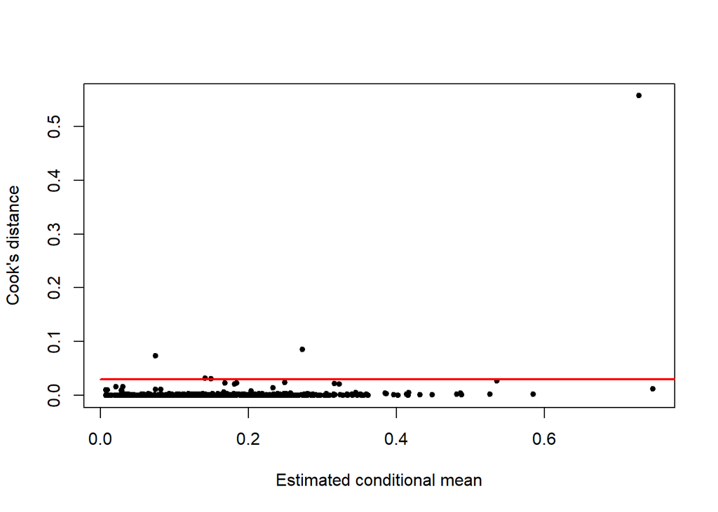

```r
yhat <- predict(m4, type="response")
plot(yhat, cooks.distance(m4), pch=20, xlab="Estimated conditional mean", ylab="Cook's distance")
lines(c(0,10), c(0.03,0.03), col="red", lwd=2)
```

```r
seismic_data2 <- seismic_data[cooks.distance(m4)<0.03,]
m5 <- glm(class~shift + gpuls + nbumps + nbumps2 + nbumps3 + nbumps4 + nbumps5 + shift*nbumps + shift*nbumps3 + shift*nbumps4 + gpuls*nbumps + nbumps*nbumps2 + nbumps*nbumps3, family=poisson(), data=seismic_data2)
summary(m5)
```

```
##
## Call:
## glm(formula = class ~ shift + gpuls + nbumps + nbumps2 + nbumps3 +
##     nbumps4 + nbumps5 + shift * nbumps + shift * nbumps3 + shift *
##     nbumps4 + gpuls * nbumps + nbumps * nbumps2 + nbumps * nbumps3,
##     family = poisson(), data = seismic_data2)
##
## Coefficients:
##                  Estimate Std. Error z value Pr(>|z|)
## (Intercept)    -5.036e+00  3.821e-01 -13.178  < 2e-16 ***
## shiftW          1.397e+00  4.324e-01   3.232  0.00123 **
## gpuls           6.448e-04  1.552e-04   4.156 3.24e-05 ***
## nbumps          1.152e+12  7.429e+12   0.155  0.87677
## nbumps2        -1.152e+12  7.429e+12  -0.155  0.87677
## nbumps3        -1.152e+12  7.429e+12  -0.155  0.87677
## nbumps4        -1.152e+12  7.429e+12  -0.155  0.87677
## nbumps5        -1.152e+12  7.429e+12  -0.155  0.87677
## shiftW:nbumps  -6.081e-01  4.149e-01  -1.466  0.14276
## shiftW:nbumps3 -1.670e-01  6.231e-01  -0.268  0.78871
## shiftW:nbumps4  2.345e+01  1.714e+05   0.000  0.99989
## gpuls:nbumps   -8.397e-05  5.246e-05  -1.601  0.10948
## nbumps:nbumps2 -7.017e-02  3.423e-02  -2.050  0.04038 *
## nbumps:nbumps3 -3.178e-02  3.313e-02  -0.959  0.33742
## ---
## Signif. codes:  0 '***' 0.001 '**' 0.01 '*' 0.05 '.' 0.1 ' ' 1
##
## (Dispersion parameter for poisson family taken to be 1)
##
##     Null deviance: 910.73  on 2578  degrees of freedom
## Residual deviance: 736.52  on 2565  degrees of freedom
## AIC: 1096.5
##
## Number of Fisher Scoring iterations: 25
```

```r
tmp <- cbind(coefficients(m4), coefficients(m5))
colnames(tmp) <- c("All data", "Filtered by leverage")
tmp
```

```
##                     All data Filtered by leverage
## (Intercept)    -4.960938e+00        -5.036006e+00
## shiftW          1.359869e+00         1.397274e+00
## gpuls           6.244261e-04         6.448403e-04
## nbumps          3.613346e+00         1.152017e+12
## nbumps2        -2.510468e+00        -1.152017e+12
## nbumps3        -2.206273e+00        -1.152017e+12
## nbumps4        -6.440755e-01        -1.152017e+12
## nbumps5        -3.316269e+00        -1.152017e+12
## shiftW:nbumps  -3.361243e-01        -6.080508e-01
## shiftW:nbumps3 -4.652659e-01        -1.669674e-01
## shiftW:nbumps4 -2.486899e+00         2.345014e+01
## gpuls:nbumps   -7.961825e-05        -8.397174e-05
## nbumps:nbumps2 -7.225735e-02        -7.016761e-02
## nbumps:nbumps3 -3.009572e-02        -3.177973e-02
```

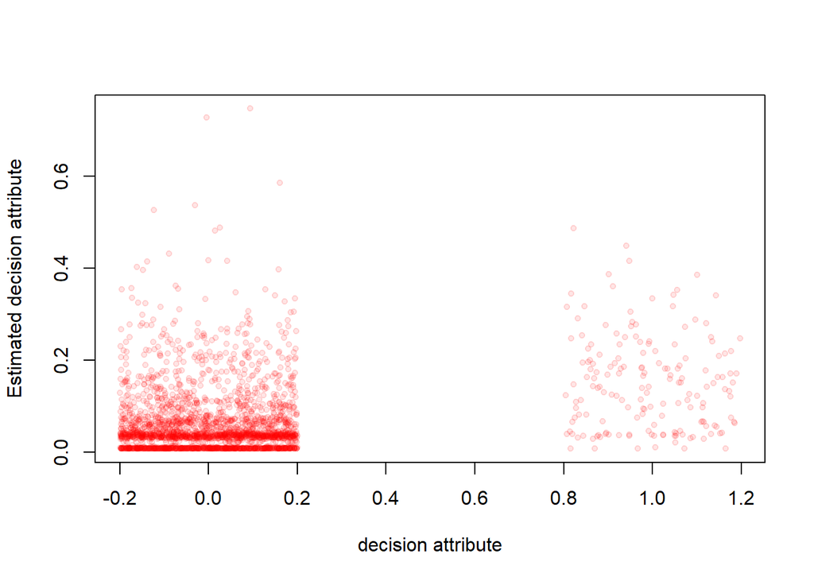

The exponents of the coefficients of the final model and confidence intervals for them:

```
##         shiftW          gpuls         nbumps        nbumps2        nbumps3
##     3.89568423     1.00062462    37.08993734     0.08123021     0.11011028
##        nbumps4        nbumps5  shiftW:nbumps shiftW:nbumps3 shiftW:nbumps4
##     0.52514779     0.03628798     0.71453427     0.62796812     0.08316747
##   gpuls:nbumps nbumps:nbumps2 nbumps:nbumps3
##     0.99992038     0.93029146     0.97035264
```

```
##                      2.5 %      97.5 %
## shiftW         1.818525889   9.3651850
## gpuls          1.000299177   1.0009152
## nbumps         1.958123831 216.3703268
## nbumps2        0.008428309   1.8057544
## nbumps3        0.020055921   2.0480652
## nbumps4        0.048652355  11.5211751
## nbumps5        0.001141370   1.1155278
## shiftW:nbumps  0.323946827   1.9709285
## shiftW:nbumps3 0.154067900   2.2240548
## shiftW:nbumps4 0.014127630   0.6596384
## gpuls:nbumps   0.999815111   1.0000246
## nbumps:nbumps2 0.865473073   0.9906570
## nbumps:nbumps3 0.903983905   1.0298652
```

Conclusions:

Shift Type: Coal-getting shifts (W) have a higher risk (3.9 times higher) of high energy seismic bumps compared to preparation shifts. (1.82, 9.37).

Seismic Activity:

Each additional pulse recorded by GMax increases the odds of a high energy seismic bump by a factor of 1.0006, with a very narrow confidence interval (1.0003, 1.0009), suggesting a very slight effect.

Each additional seismic bump recorded increases the odds of a high energy seismic bump by a factor of 37.09. However, the confidence interval is very wide (1.96, 216.37), indicating considerable uncertainty in this estimate.

Energy Range of Bumps: The impact of seismic bumps varies across different energy ranges, with higher energy bumps (nbumps5) having a much lower odds ratio. But the confidence intervals vary widely, suggesting differing levels of uncertainty.

Interactions:

The interaction of coal-getting shifts with seismic bumps in the energy range $[10^4,10^5)$ significantly lowers the odds of a high energy seismic bump by 92% (CI: 0.01, 0.66), pointing to strong safety measures in these shifts for higher energy bumps.

The combined effect of the number of pulses and seismic bumps on the occurrence of a high energy seismic bump is almost negligible (odds ratio: 0.9999; CI: 0.9998, 1), indicating the number of pulses does not significantly influence seismic risks when combined with the number of bumps.

The interaction between the total number of seismic bumps and the number of seismic bumps in the energy range $[10^2,10^3)$ decreases the odds of a high energy seismic bump by 7% (CI: 0.87, 0.99). This suggests a slight mitigating effect when these specific ranges of seismic bumps occur together.

The interaction between the total number of seismic bumps and the number of seismic bumps in the energy range $[10^3,10^4)$ decreases the odds of a high energy seismic bump by 3% (CI: 0.9, 1.03). This indicates a small, potentially negligible combined effect for these particular ranges of seismic activity.